# COVID19 Data Hub, A curated COVID19 R Package

BARUG Meeting

Eric A. Suess

2/16/2021

# COVID19 Data Hub

Today we will introduce and discuss the [COVID19 Hub](https://covid19datahub.io) an R Package that provides access to current numbers related to COVID19.

The [COVID19 Data Hub](https://covid19datahub.io) tries to provide access to a curated collection of data from as many countries around the world as possible. It is a open source package that encourages user suggestions and contributions.

```
> install.packages("COVID19")
```

```r
library(pkgsearch)
pkg_search("covid")
```

```
## - "covid" -------------------------------------- 20 packages in 0.008 seconds -
##   #     package           version by                  @ title
##   1 100 covid19jp         0.1.0   Koji Higuchi       1M Japanese Covid-19 Da...
##   2 100 covid19france     0.1.0   Amanda Dobbyn     10M Cases of COVID-19 in...
##   3  92 covid19us         0.1.7   Amanda Dobbyn      5M Cases of COVID-19 in...
##   4  92 covid19br         0.1.1   Fabio Demarqui     3M Brazilian COVID-19 P...
##   5  92 covidregionaldata 0.8.2   Sam Abbott         2M Subnational Data for...
##   6  89 covid19swiss      0.1.0   Rami Krispin       5M COVID-19 Cases in Sw...
##   7  86 covidprobability  0.1.0   Eric Brown         6d Estimate the Unit-Wi...
##   8  86 oxcovid19         0.1.2   Ernest Guevarra    4M An R API to the Oxfo...
##   9  86 COVID19           2.3.2   Emanuele Guidotti  1M R Interface to COVID...
##  10  78 coronavirus       0.3.21  Rami Krispin      18d The 2019 Novel Coron...
```

# About me

I am a Professor at [CSU East Bay](https://www.csueastbay.edu/index.html) in [Statistics and Biostatistics](https://www.csueastbay.edu/statistics/), jointly appointed in the [Engineering](https://www.csueastbay.edu/engineering/). I have taught classes in Economics, Marketing, and Analytics for the College of Business. I am 5+ years former Chair, after 3 terms, so 9 years (or 14).

I am the Chief Statistician at [machineVantage](https://machinevantage.com/) an AI and ML Neuroscience Marketing start-up company located in Berkeley, CA, Chennai and Bangalore, India, London, England. I am a <= 10 hour per week employee. Apply ML and AI algorithms for clients.

Now I am starting to work on the [COVID19 Data Hub](https://covid19datahub.io) with Emanuele Guidotti and David Ardia. Emanuele is located in Switzerland and David is located in Montreal.

# Why?

Well at the start of the Covid lock-down I decided *not* to say **No** to any project that came my way. I am now working on many interesting projects. This is the one that is likely to influence my teaching the most in terms of technical skills.

Joe asked and I said **Yes**.

I am hoping this effort is beneficial to:

```
 1. The developers of the package.
 2. The R community.
 3. The R Consortium Covid19 Working Group.
 4. My CSU East Bay colleagues, Ayona Chatterjee and Eric Fox.
 5. My current students who are working on Covid19 data projects.
 6. Me.  Hopefully I can develop more "developer" skills that I can pass on to my students.
```

# COVID19 Data Hub

The CODID19 Data Hub is an R package that pulls data from a curated collection of data [sources](https://github.com/covid19datahub/COVID19/blob/master/inst/extdata/src.csv) that is updated hourly. The data is downloaded and merged together into one file once an hour and can be access through one function in R (or using other frontends).

```
> library(COVID19)
> x_USA <- covid19("USA")
> x_USA
```

The [data](https://covid19datahub.io/articles/data.html) is downloaded from many many data sources by code running on a GCP server in the Cloud. The data is processed from the various sources to populate [three levels of data](https://covid19datahub.io/articles/doc/data.html). At the end of each day a vintage dataset is made a available.

The levels:

- administrative_area_level_1 = *Country* level data, totals
- administrative_area_level_2 = *State* level data
- administrative_area_level_3 = *County* level data

# COVID19 Data Hub

There are so many different sources of COVID19 data. Every country, every state and every city has its own data. There are many different government websites, many universities, and many companies.

- [Our World Data](https://ourworldindata.org/covid-vaccinations)
- [The Covid Tracking Project](https://covidtracking.com)
- [John Hopkins University](https://github.com/CSSEGISandData/COVID-19)
- [New York Times](https://github.com/nytimes/covid-19-data)

It is going to be an ongoing challenge to maintain all of the connections to the original sources. It is already the case that some of the original sources will be ending their efforts soon.

# What can you do with the data?

Below are some examples of the use of some possible uses of the data. I am currently teaching a Time Series course using the [fpp3](https://otexts.com/fpp3/) book and a graduate Statistical Learning class using the [mdsr2e](https://otexts.com/fpp3/) book. So the examples that follow use of of the R packages used in these books.

There is also an excellent tutorial posted on Medium’s Toward Data Science [COVID-19 Data Acquisition in R](https://towardsdatascience.com/r-interface-to-covid-19-data-hub-244ae056af2c) that give further details on how to extend the dataset in real time.

```r
library(pacman)
p_load(COVID19, tidyverse, fpp3, naniar)
```

Load the country level data for the United States.

```r
x_USA <- covid19("USA", verbose = FALSE)
```

Time plot of the cumulative deaths.

```
## Using `date` as index variable.
```

```
## Plot variable not specified, automatically selected `.vars = deaths`
```

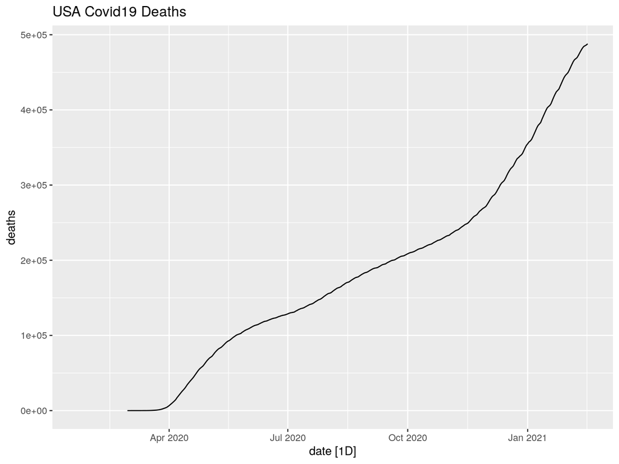

```r
x_USA %>% select(date, deaths) %>%
  as_tsibble() %>%
  autoplot() +
  labs(title = "USA Covid19 Deaths")
```

Using the lag() function we can determine daily counts.

```r
x_USA %>% select(date, deaths) %>%
  mutate(daily_deaths = deaths - lag(deaths)) %>%
  as_tsibble() %>%
  tail(10)
```

```
## Using `date` as index variable.
```

```
## # A tsibble: 10 x 4 [1D]
## # Groups:    id [1]
##    id    date       deaths daily_deaths
##    <chr> <date>      <dbl>        <dbl>
##  1 USA   2021-02-07 468204         1314
##  2 USA   2021-02-08 469786         1582
##  3 USA   2021-02-09 472818         3032
##  4 USA   2021-02-10 476100         3282
##  5 USA   2021-02-11 479257         3157
##  6 USA   2021-02-12 482142         2885
##  7 USA   2021-02-13 484301         2159
##  8 USA   2021-02-14 485384         1083
##  9 USA   2021-02-15 486325          941
## 10 USA   2021-02-16 487927         1602
```

Plotting the daily counts reveals a weekly seasonal pattern in the time series.

```
## Using `date` as index variable.
```

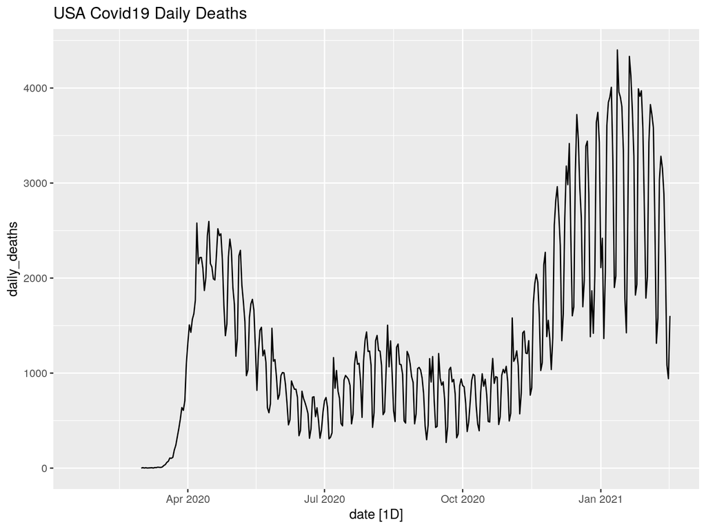

```r
x_USA %>% select(date, deaths) %>%
  mutate(daily_deaths = deaths - lag(deaths)) %>%
  as_tsibble() %>%
  autoplot(daily_deaths) +
  labs(title = "USA Covid19 Daily Deaths")
```

Looking at the last 6 months.

```
## Using `date` as index variable.
```

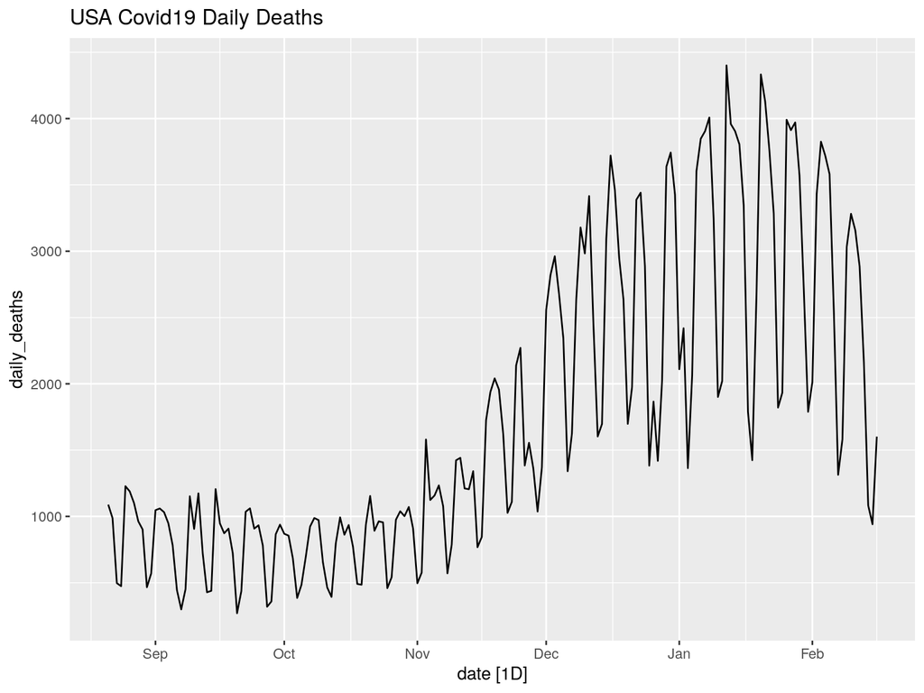

```r
x_USA %>% select(date, deaths) %>%
  mutate(daily_deaths = deaths - lag(deaths)) %>%
  as_tsibble() %>%
  tail(180) %>%
  autoplot(daily_deaths) +
  labs(title = "USA Covid19 Daily Deaths")
```

Trying a multiplicative Classical Decomposition Model to see the Trend and Seasonal components in the time series.

```
## Using `date` as index variable.
```

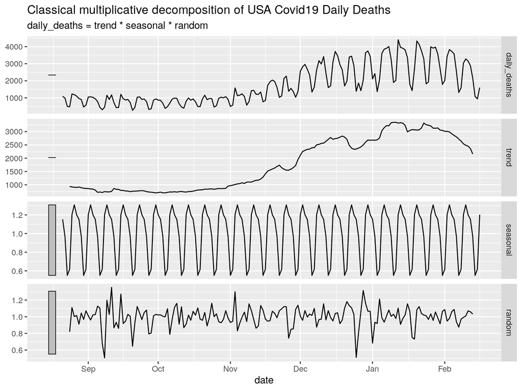

```r
x_USA %>% select(date, deaths) %>%
  mutate(daily_deaths = deaths - lag(deaths)) %>%
  as_tsibble() %>%
  tail(180) %>%
  model(classical_decomposition(daily_deaths, type = "multiplicative")) %>%
  components() %>%
  autoplot() +
  labs(title = "Classical multiplicative decomposition of USA Covid19 Daily Deaths")
```

Computing some features of the time series.

```r
x_USA %>% select(date, deaths) %>%
  mutate(daily_deaths = deaths - lag(deaths)) %>%
  as_tsibble() %>%
  tail(180) %>%
  select(date, daily_deaths) %>%
  features(daily_deaths, feat_stl)
```

```
## Using `date` as index variable.
```

```
## # A tibble: 1 x 9
##   trend_strength seasonal_streng~ seasonal_peak_w~ seasonal_trough~ spikiness
##            <dbl>            <dbl>            <dbl>            <dbl>     <dbl>
## 1          0.951            0.864                6                3   562421.
## # ... with 4 more variables: linearity <dbl>, curvature <dbl>,
## #   stl_e_acf1 <dbl>, stl_e_acf10 <dbl>
```

Autocorrelation plot. (See Allison Horst’s new series on the ACF post on Twitter @allison_horst yesterday. )

```
## Using `date` as index variable.
```

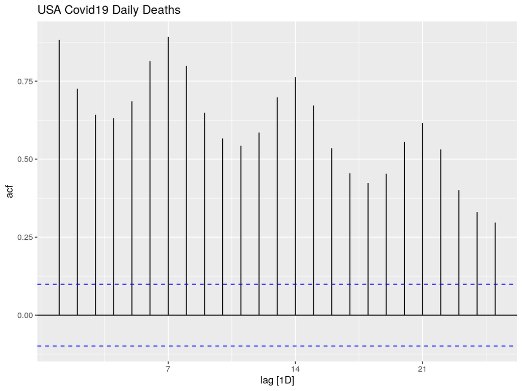

```r
x_USA %>% select(date, deaths) %>%
  mutate(daily_deaths = deaths - lag(deaths)) %>%
  as_tsibble() %>%
  ACF(daily_deaths) %>%
  autoplot() +
  labs(title = "USA Covid19 Daily Deaths")
```

PACF

```
## Using `date` as index variable.
```

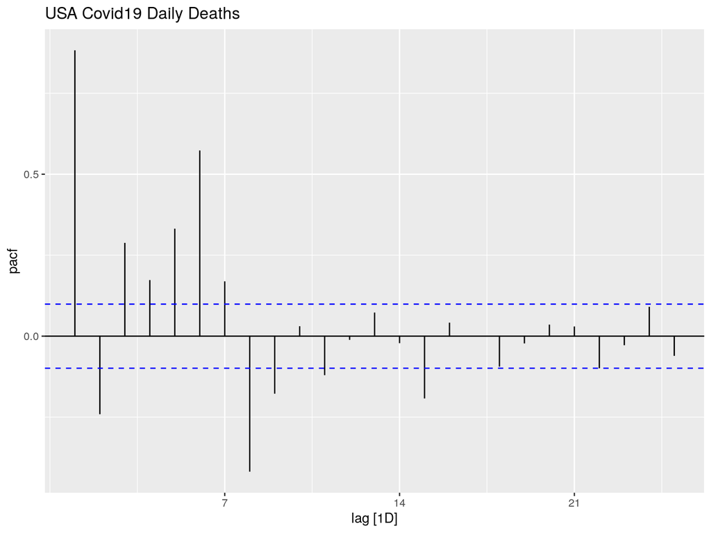

```r
x_USA %>% select(date, deaths) %>%
  mutate(daily_deaths = deaths - lag(deaths)) %>%
  as_tsibble() %>%
  PACF(daily_deaths) %>%
  autoplot() +
  labs(title = "USA Covid19 Daily Deaths")
```

Note: The time series is not stationary, so need to take another difference.

# Comparisons

Brazil

```r
x_BRA <- covid19("BRA", verbose = FALSE)
tail(x_BRA, 10)
```

```
## # A tibble: 10 x 36
## # Groups:   id [1]
##    id    date       vaccines tests confirmed recovered deaths  hosp  vent   icu
##    <chr> <date>        <dbl> <dbl>     <dbl>     <dbl>  <dbl> <dbl> <dbl> <dbl>
##  1 BRA   2021-02-07  3553681    NA   9524640   8467982 231534    NA    NA    NA
##  2 BRA   2021-02-08  3605538    NA   9524640   8478818 231534    NA    NA    NA
##  3 BRA   2021-02-09  3820207    NA   9599565   8577207 233520    NA    NA    NA
##  4 BRA   2021-02-10  4120332    NA   9659167   8616282 234850    NA    NA    NA
##  5 BRA   2021-02-11  4406835    NA   9713909   8637050 236201    NA    NA    NA
##  6 BRA   2021-02-12  4696136    NA   9765455   8691664 237489    NA    NA    NA
##  7 BRA   2021-02-13  5125206    NA   9809754   8740445 238532    NA    NA    NA
##  8 BRA   2021-02-14  5236943    NA   9834513   8765048 239245    NA    NA    NA
##  9 BRA   2021-02-15  5293979    NA   9866710   8821887 239773    NA    NA    NA
## 10 BRA   2021-02-16  5609937    NA   9921981   8847264 240940    NA    NA    NA
## # ... with 26 more variables: population <dbl>, school_closing <int>,
## #   workplace_closing <int>, cancel_events <int>,
## #   gatherings_restrictions <int>, transport_closing <int>,
## #   stay_home_restrictions <int>, internal_movement_restrictions <int>,
## #   international_movement_restrictions <int>, information_campaigns <int>,
## #   testing_policy <int>, contact_tracing <int>, stringency_index <dbl>,
## #   iso_alpha_3 <chr>, iso_alpha_2 <chr>, iso_numeric <int>, currency <chr>,
## #   administrative_area_level <chr>, administrative_area_level_1 <chr>,
## #   administrative_area_level_2 <chr>, administrative_area_level_3 <chr>,
## #   latitude <dbl>, longitude <dbl>, key <lgl>, key_apple_mobility <chr>,
## #   key_google_mobility <chr>
```

```
## Using `date` as index variable.
```

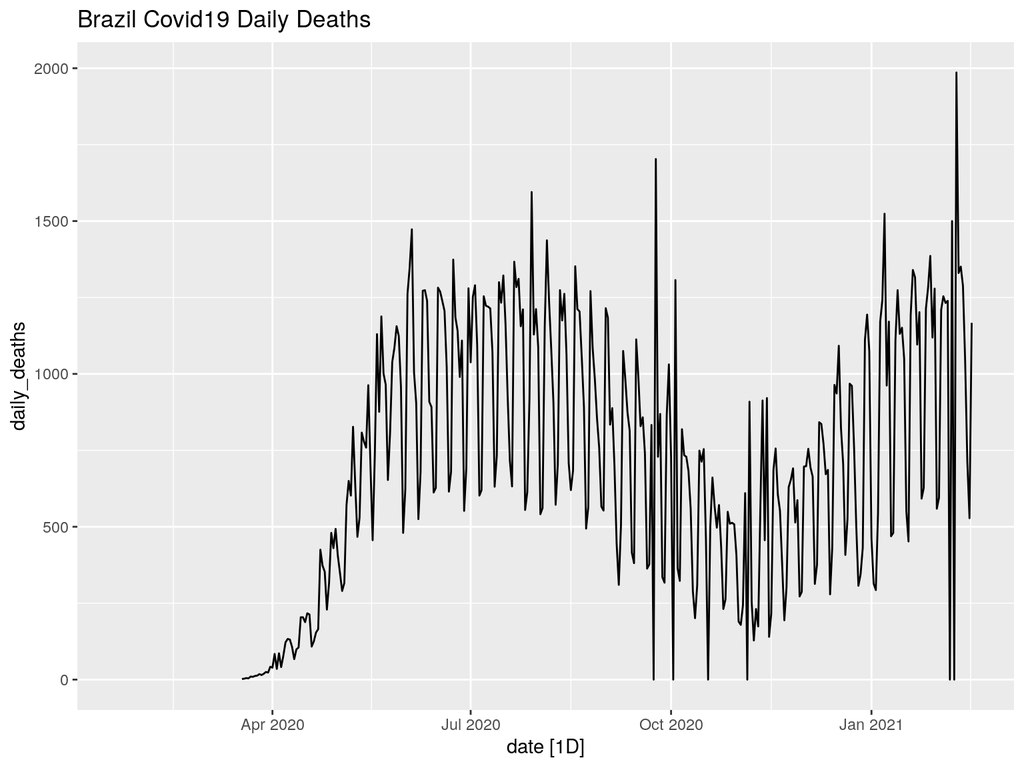

```r
x_BRA %>% select(date, deaths) %>%
  mutate(daily_deaths = deaths - lag(deaths)) %>%
  as_tsibble() %>%
  autoplot(daily_deaths) +
  labs(title = "Brazil Covid19 Daily Deaths")
```

```r
x_USA_BRA <- covid19(c("USA","BRA"), verbose = FALSE)
tail(x_USA_BRA, 10)
```

```
## # A tibble: 10 x 36
## # Groups:   id [1]
##    id    date       vaccines   tests confirmed recovered deaths  hosp  vent
##    <chr> <date>        <dbl>   <dbl>     <dbl>     <dbl>  <dbl> <dbl> <dbl>
##  1 USA   2021-02-07 41210937  3.11e8  27007368        NA 468204 81439    NA
##  2 USA   2021-02-08 42417617  3.12e8  27097095        NA 469786 80055    NA
##  3 USA   2021-02-09 43206190  3.12e8  27192455        NA 472818 79179    NA
##  4 USA   2021-02-10 44769970 NA       27287159        NA 476100 76979    NA
##  5 USA   2021-02-11 46390270 NA       27392512        NA 479257 74225    NA
##  6 USA   2021-02-12 48410558 NA       27492023        NA 482142    NA    NA
##  7 USA   2021-02-13 50641884 NA       27575344        NA 484301    NA    NA
##  8 USA   2021-02-14 52884356 NA       27640282        NA 485384    NA    NA
##  9 USA   2021-02-15       NA NA       27694226        NA 486325    NA    NA
## 10 USA   2021-02-16 55220364 NA       27753824        NA 487927    NA    NA
## # ... with 27 more variables: icu <dbl>, population <dbl>,
## #   school_closing <int>, workplace_closing <int>, cancel_events <int>,
## #   gatherings_restrictions <int>, transport_closing <int>,
## #   stay_home_restrictions <int>, internal_movement_restrictions <int>,
## #   international_movement_restrictions <int>, information_campaigns <int>,
## #   testing_policy <int>, contact_tracing <int>, stringency_index <dbl>,
## #   iso_alpha_3 <chr>, iso_alpha_2 <chr>, iso_numeric <int>, currency <chr>,
## #   administrative_area_level <chr>, administrative_area_level_1 <chr>,
## #   administrative_area_level_2 <chr>, administrative_area_level_3 <chr>,
## #   latitude <dbl>, longitude <dbl>, key <lgl>, key_apple_mobility <chr>,
## #   key_google_mobility <chr>
```

```
## `mutate_if()` ignored the following grouping variables:
## Column `id`
```

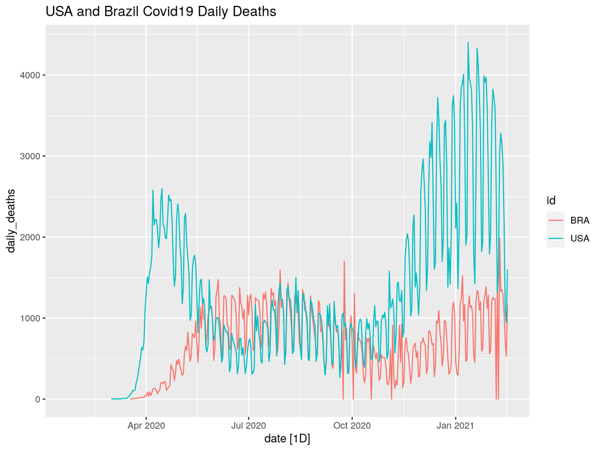

```r
x_USA_BRA %>% select(date, deaths) %>%
  mutate(daily_deaths = deaths - lag(deaths)) %>%
  as_tsibble(key = id, index = date) %>%
  autoplot(daily_deaths) +
  labs(title = "USA and Brazil Covid19 Daily Deaths")
```

Estonia, Lithuania, and Latvia

```r
x_three <- covid19(c("EST","LTU","LVA"), verbose = FALSE)
tail(x_three, 10)
```

```
## # A tibble: 10 x 36
## # Groups:   id [1]
##    id    date       vaccines  tests confirmed recovered deaths  hosp  vent   icu
##    <chr> <date>        <dbl>  <dbl>     <dbl>     <dbl>  <dbl> <dbl> <dbl> <dbl>
##  1 LVA   2021-02-07    32251 1.24e6     71800     59897   1339    NA    NA    NA
##  2 LVA   2021-02-08    32662 1.25e6     72088     60117   1347    NA    NA    NA
##  3 LVA   2021-02-09    32846 1.26e6     72869     60798   1363    NA    NA    NA
##  4 LVA   2021-02-10    33459 1.27e6     73859     61889   1395    NA    NA    NA
##  5 LVA   2021-02-11    35201 1.28e6     74701     62844   1416    NA    NA    NA
##  6 LVA   2021-02-12    36879 1.30e6     75509     62844   1431    NA    NA    NA
##  7 LVA   2021-02-13    37278 1.31e6     76282     64528   1443    NA    NA    NA
##  8 LVA   2021-02-14    37298 1.31e6     76706     65046   1451    NA    NA    NA
##  9 LVA   2021-02-15    38167 1.31e6     76984     65450   1468    NA    NA    NA
## 10 LVA   2021-02-16    39299 1.33e6     77697     65450   1486    NA    NA    NA
## # ... with 26 more variables: population <dbl>, school_closing <int>,
## #   workplace_closing <int>, cancel_events <int>,
## #   gatherings_restrictions <int>, transport_closing <int>,
## #   stay_home_restrictions <int>, internal_movement_restrictions <int>,
## #   international_movement_restrictions <int>, information_campaigns <int>,
## #   testing_policy <int>, contact_tracing <int>, stringency_index <dbl>,
## #   iso_alpha_3 <chr>, iso_alpha_2 <chr>, iso_numeric <int>, currency <chr>,
## #   administrative_area_level <chr>, administrative_area_level_1 <chr>,
## #   administrative_area_level_2 <chr>, administrative_area_level_3 <chr>,
## #   latitude <dbl>, longitude <dbl>, key <lgl>, key_apple_mobility <chr>,
## #   key_google_mobility <chr>
```

```
## `mutate_if()` ignored the following grouping variables:
## Column `id`
```

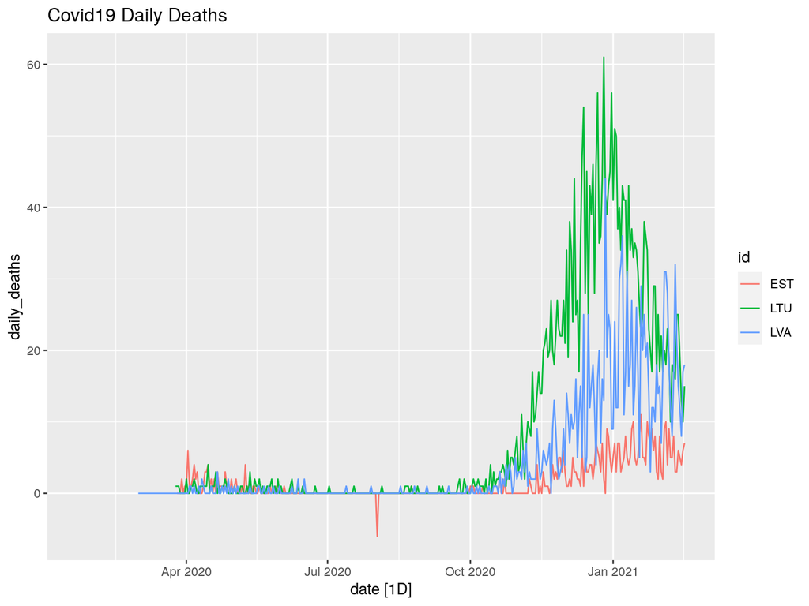

```r
x_three %>% select(date, deaths) %>%
  mutate(daily_deaths = deaths - lag(deaths)) %>%
  as_tsibble(key = id, index = date) %>%
  autoplot(daily_deaths) +
  labs(title = "Covid19 Daily Deaths")
```

Summarize the data weekly.

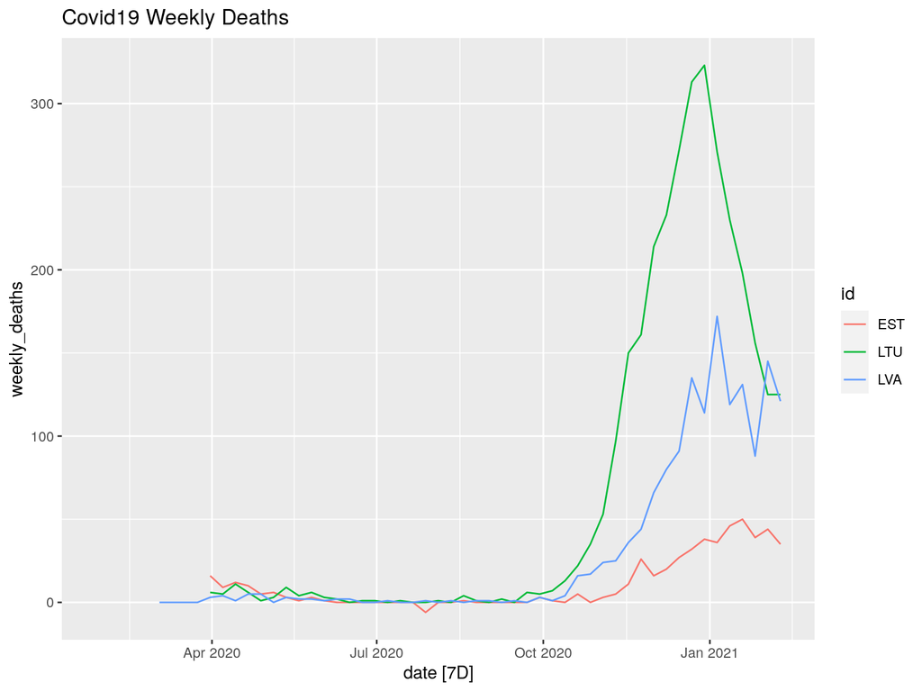

```r
x_three %>% select(date, deaths) %>%
  mutate(daily_deaths = deaths - lag(deaths)) %>%
  as_tsibble(key = id, index = date) %>%
  # Currently only supports daily data
  index_by(date) %>%
  summarise(weekly_deaths = sum(daily_deaths)) %>%
  # Compute weekly aggregates
  fabletools:::aggregate_index("1 week", weekly_deaths = sum(weekly_deaths)) %>%
  autoplot(weekly_deaths) +
  labs(title = "Covid19 Weekly Deaths")
```

# Completeness of the data

We can do a data availability study.

Estonia, Lithuania, and Latvia

```r
x_three %>% anyNA()
```

```
## [1] TRUE
```

```r
x_three %>% n_miss()
```

```
## [1] 7957
```

```r
x_three %>%  prop_miss()
```

```
## [1] 0.1879488
```

Visualize the missing values.

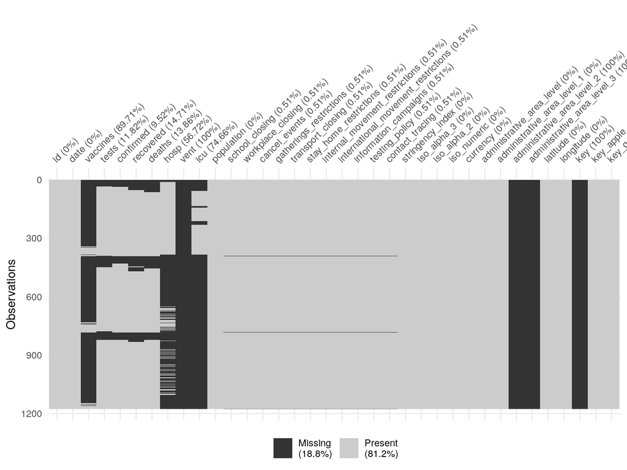

```r
library(visdat)

x_three %>% group_by(id) %>%
  vis_miss()
```

# Administrative level 2

```r
x_USA_state <- covid19("USA", level = 2)
```

[output not shown]

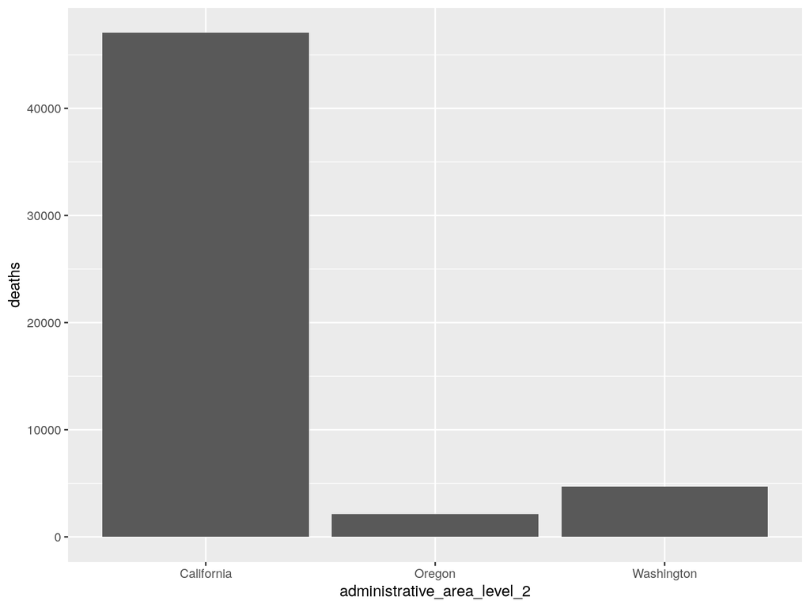

```r
x_USA_state %>% select(date, administrative_area_level_2, deaths) %>%
  filter(date == "2021-02-15") %>%
  filter(administrative_area_level_2 %in% c("California", "Oregon", "Washington")) %>%
  ggplot(aes(x = administrative_area_level_2, y = deaths)) +
  geom_bar(stat="identity")
```

# Administrative level 3

```r
x_USA_county <- covid19("USA", level = 3)
```

[output not shown]

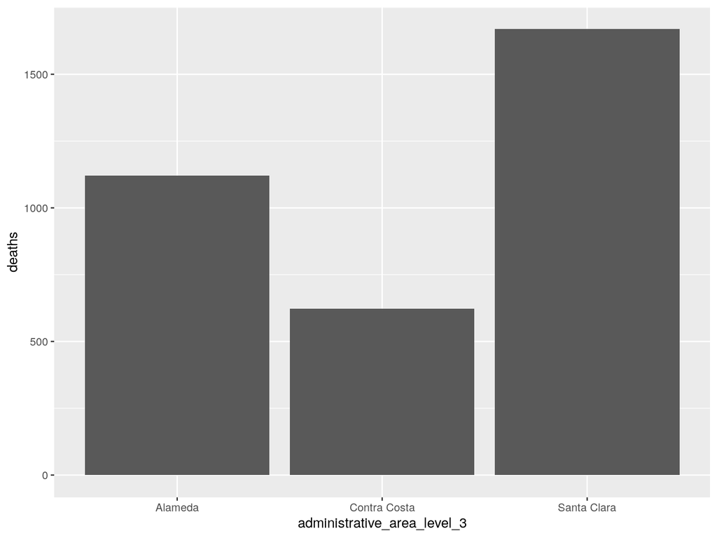

```r
x_USA_county %>% select(date, administrative_area_level_2, administrative_area_level_3, deaths, vaccines) %>%
  filter(date == "2021-02-15") %>%
  filter(administrative_area_level_2 %in% c("California")) %>%
  filter(administrative_area_level_3 %in% c("Alameda", "Contra Costa", "Santa Clara")) %>%
  ggplot(aes(x = administrative_area_level_3, y = deaths)) +
  geom_bar(stat="identity")
```

# Getting into the role

- Checking the [Issues](https://github.com/covid19datahub/COVID19/issues) everyday.
- Trying to continue the development new documentation and examples of the use of the data.
- Fully understanding the philosophy of the creators of the project.
- Recruiting others to help out. Maybe just for motivation. Please **star** the COVID19 Data Hub Project on Github.
- Putting in some hours to complete some of the Open Issues.

# Please reach out if you have any suggestions.

- On the Project Github Issues page.
- Or by email. eric.suess@csueastbay.edu